# Get to know each other!

## About me

Dr. Shuwen Tan, Assistant Professor of Marine Sciences. I use she/her pronoun, and I prefer that you call me by my first name. My office is Room 191 in the Lowell P. Weicker Jr. building, and my email is shuwen.tan@uconn.edu

I am a physical oceanographer by training, and I study ocean waves ranging from 1000km-long planetary waves (due to the Earth's rotation) to 1m-scale internal waves (due to the buoyancy of water particles).

show movie

This animation shows density layers in the South China Sea being perturbed by the regular back-and-forth tidal flow through the Luzon Strait. These leads to large amplitude internal waves (shown in red underwater, and in white when seen from above), being radiated west to the Chinese continental shelf.

[figure not shown]

I enjoy wave-watching and photography, and I also enjoy hiking, yoga, board gaming, cooking, and hanging out with my cats!

[figure not shown]

## About you

Please share the class a bit about yourself:

- What’s your name (and preferred name)?
- What pronouns do you use?
- What year are you in, and what’s your major?
- What’s your academic background?
- And just for fun — what do you like to do outside of school/work?

I’d also love to hear your expectations for this class — your input will help me shape the course to better support you! Feel free to share your expectations and any thoughts or feedback throughout the semester using this Google Form (https://docs.google.com/forms/d/e/1FAIpQLSfaArgm-KJQl-Dj991iK-TPB4prWjb48T8KX1Ax6KkhAPF9HQ/viewform). The form is anonymous, but if you’d like to include your name, you’re welcome to add it in your response.

## Why do we care about coastal circulation and sediment transport?

- coastal circulation: transport of heat, fresh water, nutrients, lavae, sediment
- sediment transport: impacted by circulation, sea level change, tides, waves, shapes coastal morphology, impacting coastal ecosystem, human life, etc.

[figure not shown]

# Some Housekeeping

## Course Requirements and Grading policies

Students are required to actively participate in the class (10 pts), complete 8 assign- ments (40 pts, equally weighted, there will be 8 bonus point for those who com- plete or partially complete grad student exercises), a group project (20 pts), and a final’s (30 pts) exam.

All due dates will be identified on HuskyCT. Deadlines are 11:59 pm Eastern Standard Time. If you have a good reason (caregiving, illness, hardships), please do not hesitate to ask for an extension prior to the deadline. No late assignments will be accepted unless pre- viously discussed with me. Students with learning disabilities are eligible for extended due dates and other accommodations through the Center for Students with Disabilities.

I will strive to provide feedback on your assignments within a week of the due date. Students who wish to dispute a grade on an assessment must do so within 1 week of the grade being posted.

## Textbook(s) and Software Requirements

[Introduction to Coastal Processes and Geomorphology](https://www.cambridge.org/highereducation/books/introduction-to-coastal-processes-and-geomorphology/E1F336231A754F0DD06BD4174B2530E7#overview) by Davidson-Arnott et al.

[Coastal Dynamics](https://books.open.tudelft.nl/home/catalog/book/202) by Bosboom and Stive

I will be presenting the required material in lecture format with reading as supplemental to your knowledge. You will not be required to know material from the textbook that was not discussed in class or presented as homework.

Students can use either their own or a shared computer to access interactive class notes and complete assignments. Note, this is not a coding class but the class note and assignments will include blocks of Python code that demonstrate data visualization and research computing (e.g., the code block below plots the significant wave height observed at an ocean station in Kailo, Majuro, Marshall Islands.). No prior programming experience is required. The intention is to provide you with ample examples in both the class notes and assignments so you can follow along. You can either run the code on your laptop (required for grad students) or [Google Colab](https://colab.research.google.com/).

If you use MacOS or Linux, you only need a terminal running bash. If you use Windows you may use (Windows terminal). You will be instructed to install different software and set up an “environment” on your laptop. Regardless of your operating system, If you don’t have your own laptop, it is recommended to sign up for a Google account to access Google Colab, where you can run example Python scripts and complete assignments. This platform allows you to program directly in a web browser without requiring any local setup.

```
<xarray.Dataset> Size: 20MB
Dimensions:                     (sourceCount: 3444, waveTime: 3623,
                                 metaBoundsCount: 2, waveFrequency: 100,
                                 sstTime: 21694, gpsTime: 21689,
                                 acmTime: 10845, dwr4Time: 3622,
                                 upcrossTime: 3623, upcrossQuantileLength: 23,
                                 syncTime: 3623, cat4Time: 21693)
Coordinates:
  * waveTime                    (waveTime) datetime64[ns] 29kB 2025-06-05T02:...
  * waveFrequency               (waveFrequency) float32 400B 0.025 0.03 ... 1.0
  * sstTime                     (sstTime) datetime64[ns] 174kB 2025-06-05T02:...
  * gpsTime                     (gpsTime) datetime64[ns] 174kB 2025-06-05T02:...
  * acmTime                     (acmTime) datetime64[ns] 87kB 2025-06-05T02:0...
  * dwr4Time                    (dwr4Time) datetime64[ns] 29kB 2025-06-05T02:...
  * upcrossTime                 (upcrossTime) datetime64[ns] 29kB 2025-06-05T...
  * syncTime                    (syncTime) datetime64[ns] 29kB 2025-06-05T02:...
  * cat4Time                    (cat4Time) datetime64[ns] 174kB 2025-06-05T02...
    metaDeployLatitude          float32 4B ...
    metaDeployLongitude         float32 4B ...
Dimensions without coordinates: sourceCount, metaBoundsCount,
                                upcrossQuantileLength
Data variables: (12/120)
    sourceFilename              (sourceCount) object 28kB ...
    waveTimeBounds              (waveTime, metaBoundsCount) datetime64[ns] 58kB ...
    waveFlagPrimary             (waveTime) float32 14kB ...
    waveFlagSecondary           (waveTime) float32 14kB ...
    waveHs                      (waveTime) float32 14kB ...
    waveTp                      (waveTime) float32 14kB ...
    ...                          ...
    waveA2Value                 (waveTime, waveFrequency) float32 1MB ...
    waveB2Value                 (waveTime, waveFrequency) float32 1MB ...
    waveCheckFactor             (waveTime, waveFrequency) float32 1MB ...
    waveSpread                  (waveTime, waveFrequency) float32 1MB ...
    waveM2Value                 (waveTime, waveFrequency) float32 1MB ...
    waveN2Value                 (waveTime, waveFrequency) float32 1MB ...
Attributes: (12/68)
    naming_authority:                edu.ucsd.cdip
    keywords_vocabulary:             Global Change Master Directory (GCMD) Ea...
    date_created:                    2025-08-19T13:46:42Z
    date_issued:                     2025-08-19T13:46:42Z
    date_modified:                   2025-08-19T13:46:42Z
    creator_name:                    Coastal Data Information Program, SIO/UCSD
    ...                              ...
    instrument:                      metaInstrumentation
    platform:                        wave_buoy
    platform_vocabulary:             http://mmisw.org/ont/ioos/platform
    platform_name:                   KALO, MAJURO, MARSHALL ISLANDS BUOY - 163p1
    DODS.strlen:                     0
    DODS.dimName:                    metaStationNameLength
```

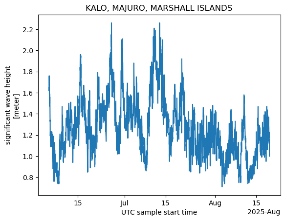

```python
# import python libraries
import xarray as xr
import numpy as np
from matplotlib import cm
import matplotlib.pyplot as plt

# load wave data (https://cdip.ucsd.edu/m/products/?stn=163p1)
opendap_url = 'http://thredds.cdip.ucsd.edu/thredds/dodsC/cdip/realtime/163p1_rt.nc'
ds = xr.open_dataset(opendap_url, engine='netcdf4')
ds.waveHs.plot()
plt.title('KALO, MAJURO, MARSHALL ISLANDS')
ds
```

## Academic Integrity and Artificial Intelligence

- All work you submit must be your own, unless explicitly defined as a group assignment
- When you borrow or closely imitate another’s ideas or language, you must acknowledge this in your assignments. This includes crediting your peers’ assistance on assignments and citing the published references that you use.
- You must also acknowledge the use of artificial intelligence tools

If you use any artificial intelligence (AI) software, including large language models (LLMs) and/or paraphrasing tools including but not limited to ChatGPT, Grammarly, and/or Google Gemini, to help you complete any work in this course (including for idea generation, to create/check code, to summarize text and/or to generate/revise/paraphrase text and/or media for your assignments), you must include an acknowledgement statement at the end of the assignment that briefly shares

1. what tools were used
2. how you used them
3. whether the tools were helpful and if you had to make any corrections to the work of the AI tool and why.

**Example:** Using GenAI to support learning! The documentation in the above example code may be incomplete, or you might be unsure what certain commands do. In that case, you can use AI to analyze the code and add additional documentation. AI may be useful in debugging or analyzing error messages! Also note that AI may create fake content so always evaluate AI output critically.

UConn has a contract with Microsoft for free basic access to Copilot. The contract affords privacy protections and includes an agreement that queries will not be used to train large language models. Due to these protections, it is recommended, though not required, that you use Copilot. click for more info -> [UCONN knowledge base on Microsoft Copilot](https://kb.uconn.edu/space/IKB/27707965542/Getting+Started+with+Microsoft+Copilot)

## Course objectives

By the end of this course, students will be able to:

1. Describe the **coastal zone** in terms of geomorphology and hydrodynamics, and identify the factors that control coastal evolution and morphology.
2. Identify and describe the characteristics of **ocean waves, tides, and winds**, and explain their roles in shaping coastal circulation and influencing **sea level**.
3. Understand key physical processes and their forcings in various coastal regions, including the **surf zone, inner shelf, and outer shelf environments**.
4. Explain **sediment transport mechanisms**, including bedload transport, resuspension, and deposition, and how they interact with hydrodynamic processes.
5. Understand the **impacts of coastal processes on humans**, including sea-level rise, storm surge, rip currents, coastal erosion, and related hazards.
6. Become familiar with coding and data analysis tools to process, visualize, and interpret coastal **oceanographic datasets** in support of understanding coastal processes.
7. Conduct **field observations** (I've booked some ship time, but there's still a fair amount of uncertainty) and interpret data related to coastal circulation and sediment transport. **Collaborate on a scientific project**, integrating field data and external datasets to explore a coastal oceanographic question and communicate findings effectively.
8. Evaluate the implications of coastal processes for coastal management and engineering.